# **Suspicious Counties & Incarceration Rates**

### *Introduction to “Suspicious Counties”*

Hello. I will be evaluating counties with incarceration rates (average daily jail population/total population) of values greater than 1, for any specific race (excluding “other”). I am interested in these counties as, while at first it may seem like a data collection error, it is actually very possible for a county to have such an incarceration rate above 100%, possibly due to jailing visitors that would not be counted in the total population.

The number of counties with these sorts of incarceration rates is low, especially when compared to the whole. While it is entirely possible that data has been miscollected, I have filtered out obviously incorrectly reported counties (such as those with recorded total populations of 0) and those with reported populations of 0 of the relevant race for each incarceration rate (As this would result in an incarceration rate of infinity for that incarceration rate within that county). As such, the remaining “suspicious counties” have **potenitally** accurate data.

### *Summary Information*

```
## $max_aapi_incar_rate
## [1] 19.93333
##
## $mean_aapi_incar_rate
## [1] 0.007495762
##
## $min_aapi_incar_rate
## [1] 0
##
## $suspicious_counties_aapi
##  [1] "Irwin County"        "Alexander County"    "Pulaski County"
##  [4] "Union County"        "Chase County"        "Catahoula Parish"
##  [7] "Tensas Parish"       "Carroll County"      "Torrance County"
## [10] "Jefferson County"    "Maverick County"     "Newton County"
## [13] "Throckmorton County" "Daggett County"
##
## $max_white_incar_rate
## [1] 0.7388749
##
## $mean_white_incar_rate
## [1] 0.003185
##
## $min_white_incar_rate
## [1] 0
##
## $suspicious_counties_white
## character(0)
##
## $max_black_incar_rate
## [1] 21.45
##
## $mean_black_incar_rate
## [1] 0.04393668
##
## $min_black_incar_rate
## [1] 0
##
## $suspicious_counties_black
##  [1] "Union County"          "Cassia County"         "Shoshone County"
##  [4] "Edwards County"        "Hamilton County"       "Mason County"
```

[output cut: 101 more lines]

```
##  [76] "Hudspeth County"       "King County"           "Montague County"
##  [79] "Starr County"          "Terrell County"        "Webb County"
##  [82] "Beaver County"         "Duchesne County"       "Millard County"
##  [85] "Morgan County"         "Sevier County"         "Uintah County"
##  [88] "Highland County"       "Calhoun County"        "Lincoln County"
##  [91] "Nicholas County"       "Roane County"          "Wetzel County"
##  [94] "Menominee County"      "Shawano County"        "Washington County"
##  [97] "Liberty County"        "Wibaux County"         "Antelope County"
## [100] "Bowman County"         "Emmons County"         "McHenry County"
## [103] "Wells County"          "Douglas County"        "Dickson County"
## [106] "Jack County"           "Reeves County"         "Staunton city"
## [109] "Avoyelles Parish"      "Red River Parish"      "Gosper County"
##
## $total_num_suspicious_counties
## [1] 111
```

We will be evaluating the suspicious counties by their name, number per year, state, and total number. The “All Suspicious Counties” variable is the total number across all years from 1990 to 2018. Surprisingly small, at only 111, out of the thousands of counties reported in the original dataset.

I have also broken down the Suspicious Counties by race within the summary information above. The maximum, mean, and minimum incarceration rates are useful in the scripting for this project, but will not be relevant to any of the following charts. We’re **not** focusing on the incarceration rates themselves; only on counties with incarceration rates greater than 1.00, which indicates a county’s racial residency population is LESS than that county’s jailed population for that race.

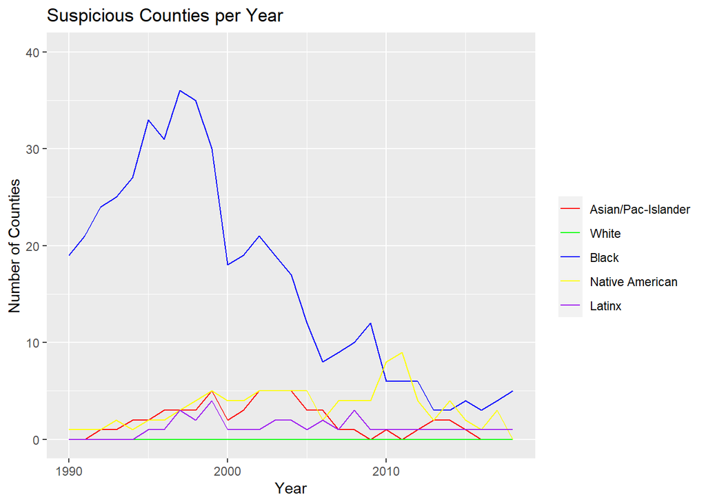

In the above line chart, we can see the number of total suspicious counties per year, divided by race. It shows us that the suspicious counties for black incarceration rates are massively higher than the other races, and even as the number of suspicious incarceration rates for races begin to near eachother, only the incarceration rates for Native Americans ever tops the yearly suspicious incarceration rate quantity of African Americans.

Another interesting - although unfortunately unsurprising trend - is that there is never a suspicious incarceration rate for White people. This could be do to a number of things, such as census data being more accurate for White people, jail data tracking being more accurate for White people, intentional disinformation by prisons and jails to attempt to keep the incarceration rates for white people down (this line of thinking is conspiratorial however, and should be conducted only with caution). The most grim possibility is the information is entirely or mostly correct, and white populations for counties are so high that it is virtually impossible, even when jailing non-residents, for there to be a white incarceration rate above 1.00

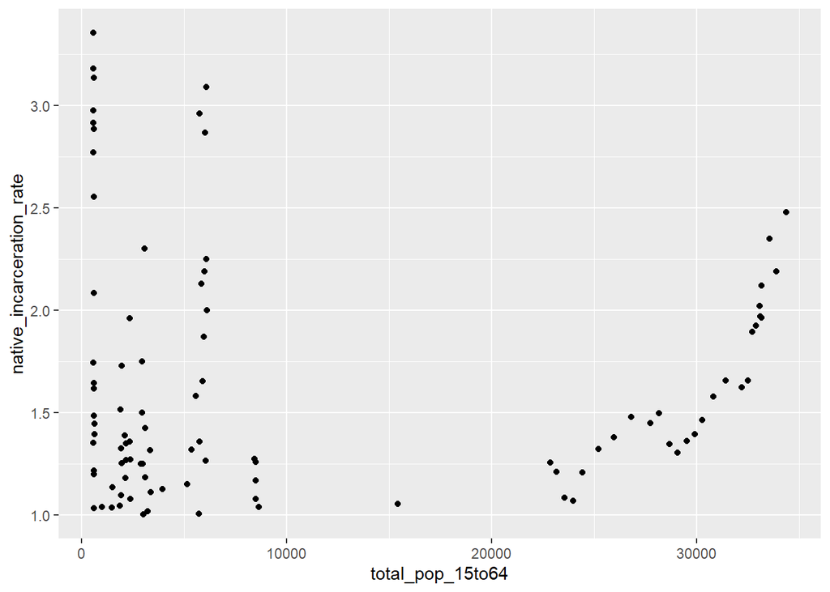

The scatter plot above compares the total population (of 15 to 64 years old, those vastly most likely to be incarcerated) of counties to the incarceration rate of native americans within that county, but only shows counties with suspiciously high native incarceration rates.

Two correlations appear, essentially divided by small total populations and relatively large total populations. At smaller total populations, suspiciously high incarceration rates are likely to be higher. This correlation is fairly strong, and corroborates the idea that these small population counties may have data collection errors, as lower sample sizes make data collection errors more prone to happen, and more noticeable when they do happen.

However, the other correlation is very surprising, and opposes the idea that suspiciously high incarceration rates are due to data collection errors. As the scatter plot shows, as relatively high total populations, the native incarceration rate for suspicious counties ALSO increases. This implies the number of incarcerated natives increases by more than 100% as total population increases in suspicious counties. This makes some sense when we realize that native americans living on reserves would not be included in the population census for counties, although they may be (illegally) jailed by police within those counties. As the size of a county increases, so does it’s infrastructure and trade viability, thus giving the nearby native reserve populations more reason to spend time in the county itself, increasing their chances of being illegally jailed.

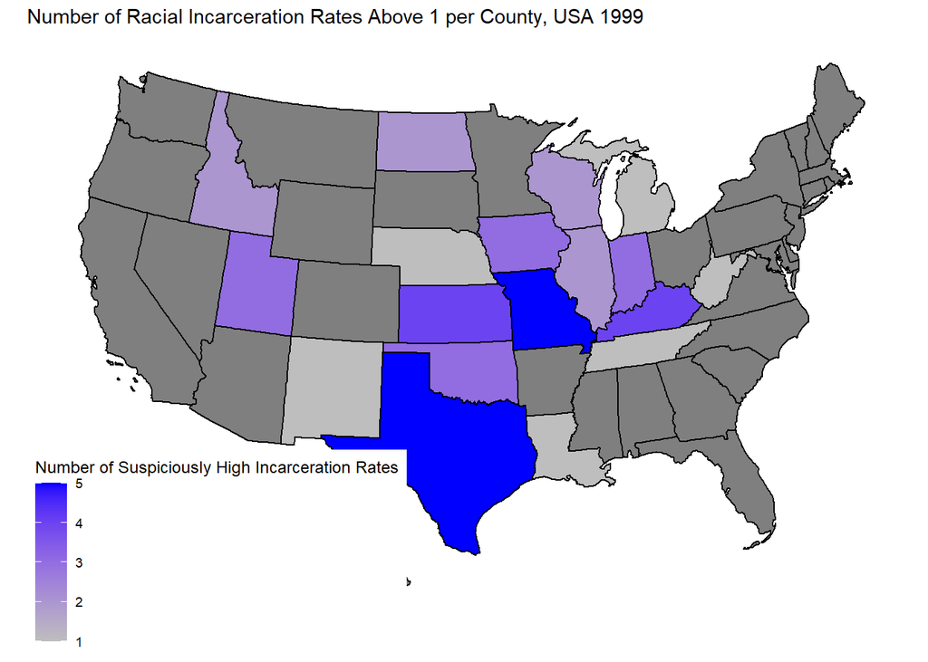

The map above shows the number of suspicious counties within each US state in the year 1999. The year 1999 was chosen because, as the the earlier line graph shows, it has a useful distribution of suspicious counties; it is still near the peak of suspiciously high black incarceration rates, but also has a fair number of all other (non-white) suspicious incarceration rates. As such, it is a reasonable approximation of the total trends in the number of suspicious incarceration rates by race over the period 1990 to 2018.

As this shows, some states are far more likely to have higher numbers of suspicious counties. Mostly around the west portions of the bible belt and frost belt, not quite the midwest, but adjacent to it. Most of the states with any amount of suspicious counties in 1999 leaned republican in their elections at the time, and they all had very low amounts of permanent immigration from other US states, with the exception of Texas.